# Personalized Design Recommendation Report

MLE-Based Analysis for Spatial CRT Treatment Assignment

Author

Andrew Walther

Published

April 8, 2026

# 1 Executive Summary

This report is a companion to the `MLE_combined_design_recommendations.pdf` figure file. It provides narrative explanations of **how each analysis was computed**, **what each figure and table shows**, and **what the results mean in practice** for researchers designing spatial cluster randomized trials (CRTs).

The simulation evaluates **8 treatment assignment designs** across **2560 parameter scenarios** using Maximum Likelihood Estimation (MLE) via a spatial autoregressive model (`lagsarlm`). The estimand is the direct treatment effect $\tau$ (primary scenario: $\tau = 1.0$; sensitivity across $\tau \in \{0.8, 1.5, 2.0, 3.0\}$ in Section 11).

Three analytical questions are addressed:

Best MLE design (lowest avg MSE) for each of the 5 incidence configurations.

| Incidence Config | Best Design | Avg MSE | Avg Coverage |
| --- | --- | --- | --- |
| iid Uniform | D3: Sat. Quadrants | 0.0788 | 0.940 |
| Poisson (rho_X = 0.20) | D8: Inc.-Guided Sat. Q. | 0.0778 | 0.939 |
| Poisson (rho_X = 0.50) | D3: Sat. Quadrants | 0.0790 | 0.939 |
| Spatial (rho_X = 0.20) | D8: Inc.-Guided Sat. Q. | 0.0778 | 0.948 |
| Spatial (rho_X = 0.50) | D3: Sat. Quadrants | 0.0754 | 0.945 |

**Key finding:** D3: Sat. Quadrants achieves the lowest average MSE in 3 of 5 incidence configurations, with D1: Checkerboard consistently worst. Spillover type (control-only vs. both) is by far the most influential parameter for all leading designs, while spatial autocorrelation $\rho$ and spillover magnitude $\gamma$ have secondary effects.

# 2 Study Background

## 2.1 Designs Evaluated

8 treatment assignment strategies are compared. Each allocates approximately 50% of the 100 clusters ($10 \times 10$ grid) to treatment:

8 treatment assignment designs evaluated. Deterministic designs (1, 2) produce one assignment and replicate it; stochastic designs resample across 25 replications.

[output not shown]

## 2.2 Performance Metrics

For each of the 2560 scenarios, **250 simulation iterations** (25 design resamples $\times$ 10 outcome resamples) produce the following metrics:

- **Bias** $= \bar{\hat{\tau}} - \tau$: average departure from true effect (primary $\tau = 1.0$)
- **SD**: standard deviation of estimates across iterations
- **MSE** $= \text{Bias}^2 + \text{SD}^2$: total estimation error; the **primary ranking criterion** throughout this report
- **Coverage**: fraction of 95% confidence intervals containing the true $\tau$

Lower MSE is better. Coverage near 0.95 (the nominal level) indicates valid inference.

## 2.3 Simulation Parameter Space

Simulation parameter grid. Each of the 2560 scenarios is a unique combination of (incidence config, nb\_type, Rho, Gamma, Spillover type, Design). Results are always reported separately by incidence config.

| Parameter | Values | Levels |
| --- | --- | --- |
| Incidence mode | iid, spatial, poisson | 5 configs |
| rho\_X (incidence spatial autocorr.) | N/A (iid); 0.2, 0.5 (Spatial, Poisson) | --- |
| nb\_type (contiguity) | queen, rook | 2 |
| Rho (outcome spatial autocorr.) | 0, 0.01, 0.2, 0.5 | 4 |
| Gamma (spillover magnitude) | 0.5, 0.6, 0.7, 0.8 | 4 |
| Spillover type | both, control_only | 2 |
| Design | 1, 2, 3, 4, 5, 6, 7, 8 | 8 |
| TOTAL |  | 2560 scenarios |

# 3 Analytical Methods

This section explains exactly how each analysis in the recommendation report is computed.

## 3.1 Core Ranking Method: `rank_designs_by_group()`

All conditional rankings in this report share the same logic, implemented in `rank_designs_by_group()`:

1. **Group** the 512 scenarios within an incidence config by the requested conditioning variables plus Design (e.g., group by `{Rho, Design}`)
2. **Aggregate**: compute average MSE, Coverage, Bias, and SD within each group
3. **Rank**: within each unique combination of the conditioning variables, assign integer ranks to designs based on ascending average MSE (rank 1 = best; ties broken using minimum rank)
4. **Return** a tidy data frame with one row per `{group, Design}` combination

This is the same ranking logic used in `table_design_ranks()` in `06_visualizations.R`, extended to support arbitrary conditioning sets.

**Critical invariant:** Rankings are **always computed within a single incidence configuration**. Results are never aggregated across the 5 incidence configs because each represents a fundamentally different assumption about how prior incidence data arises.

## 3.2 Q1 — Per-Config Rankings: `table_incidence_rankings()` and `plot_incidence_rankings()`

**What is computed:** For each of the 5 incidence configs, all 512 scenarios (8 designs $\times$ 64 parameter combinations) are summarized by computing the average MSE per design. Designs are then ranked 1–8 (lowest = best) within each config.

**What the figure shows** (Page 1 of PDF): A faceted bar chart with one panel per incidence config. Bars represent average MSE per design, sorted from lowest to highest within each panel. Rank labels (1–8) appear above each bar.

**How to read it:** Lower bars are better. Rank labels allow quick comparison across panels. A design ranked consistently high across all panels is a robust global recommendation.

## 3.3 Q2 — Marginal Rankings: `table_marginal_rankings()` and `plot_rank_trajectories()`

**What “marginal” means:** For a parameter like Rho, we want to know: ignoring all other parameters, how does each design rank when Rho takes a specific value? This is computed by grouping all scenarios by `{Rho, Design}` and averaging MSE across the remaining parameters (Gamma, Spillover_Type, Neighbor_Type).

**What the rank trajectory plot shows**: A line plot where the x-axis is the parameter level, the y-axis is design rank (1 at top, 8 at bottom), and each line traces one design. Crossing lines indicate a **rank reversal**: a design that is best at one parameter level but not at another.

**What the marginal ranking table shows**: A wide table with parameter levels as column headers and designs as rows. Each cell reports `Avg_MSE (#Rank)` at that parameter level, averaged over all other parameters. Designs are ordered by their overall rank (best at top).

**What the conditional MSE boxplot shows**: Rather than averages, this shows the **full distribution** of raw scenario-level MSE values for each design at each parameter level. This reveals whether a design’s advantage is consistent or comes from a few favorable extreme scenarios.

## 3.4 Q3 — Best Design Heatmap: `plot_best_design_heatmap()`

**What is computed:** For every combination of two parameters (e.g., Rho and Gamma), all scenarios sharing that combination are grouped, average MSE is computed per design, and the design with the minimum average MSE is identified as the winner.

**What the heatmap shows**: A grid of colored tiles where each cell corresponds to one `{Rho, Gamma}` combination. The color and text label identify the winning design. The MSE value inside each tile is the winning design’s average MSE at that combination.

**Interpretation guidance:** If one design wins all tiles, it dominates unconditionally. If tiles show different winners, the choice of design should adapt to the anticipated parameter regime.

## 3.5 Programmatic Commentary: `generate_commentary()`

For each incidence config, six structured findings are automatically derived from the results:

| Finding | Computed as |
| --- | --- |
| Overall winner | Design with Rank 1 from ungrouped `rank_designs_by_group()` |
| Dominance % | From scenario-level pairwise comparison: $\frac{\#\{s : \text{MSE}_{\text{best},s} < \text{MSE}_{\text{2nd},s}\}}{64}$ |
| Rank stability | Whether the best design holds rank 1 at every level of Rho and every level of Gamma |
| Coverage | Average Coverage for the best and worst designs |
| Sensitivity | Eta-squared ($\eta^2 = SS_{\text{between}} / SS_{\text{total}}$) for each parameter |
| Recommendation | Template string synthesizing findings 1–5 |

# 4 Q1: Design Rankings by Incidence Mode

## 4.1 Cross-Config MSE Rankings

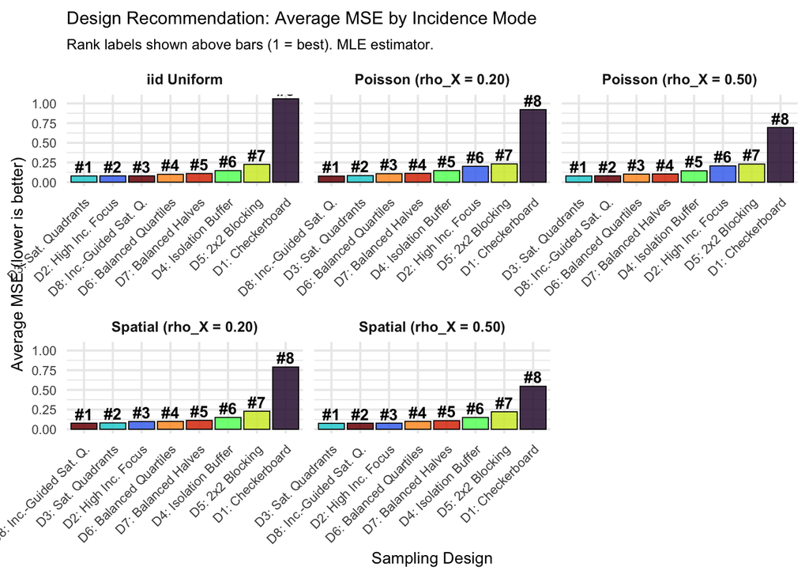

**Reading the plot:** The 5 panels correspond to the 5 incidence configurations. Within each panel, designs are arranged from best (left) to worst (right), with the rank number printed above each bar. The consistent leftward position of D3: Sat. Quadrants across all panels is the primary finding.

**Key observation:** D3: Sat. Quadrants ranks first in 3 of 5 incidence configurations, with average MSE ranging from 0.075 to 0.079 depending on the config. This 7.2–13.4x MSE advantage over the worst design (D1: Checkerboard) is stable regardless of how the historical incidence was generated.

## 4.2 Cross-Config Coverage Rankings

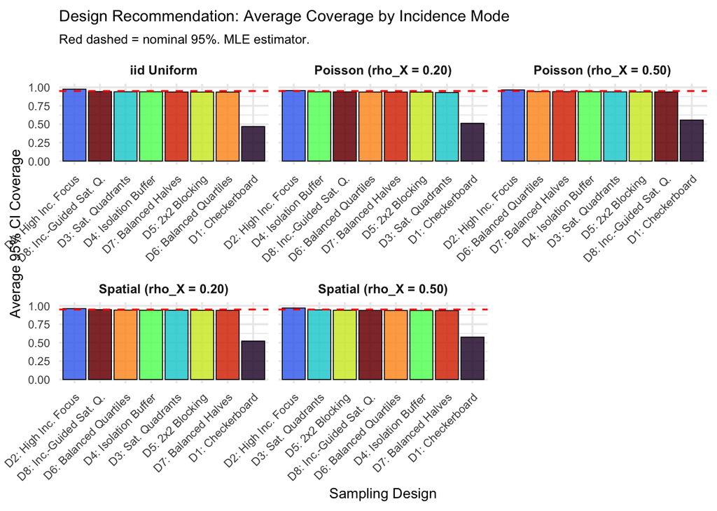

Average 95% CI coverage probability per design for each incidence configuration. Red dashed line = nominal 0.95. Coverage near 0.95 indicates valid inference; D1: Checkerboard coverage falls to 0.47–0.58 across all configs.

**Reading the plot:** The red dashed line at 0.95 is the nominal coverage target. Bars above this line are over-covering (conservative CIs); bars below are under-covering (anti-conservative). Under MLE, designs other than D1: Checkerboard all achieve reasonable coverage (0.93–0.98), but D1: Checkerboard falls dramatically short.

**Key observation:** D1: Checkerboard’s poor coverage (0.47–0.58) makes it unsuitable for inference regardless of MSE. Even in the rare scenario where its MSE is competitive, its confidence intervals are invalid.

## 4.3 Detailed Rankings by Incidence Config

MLE design rankings for iid Uniform. Runner-up MSE is 1.5% higher than the winner; worst design MSE is 13.4x higher.

| Rank | Design | Avg MSE | Avg Coverage | Avg Bias |
| --- | --- | --- | --- | --- |
| 1 | D3: Sat. Quadrants | 0.0788 | 0.940 | 0.0108 |
| 2 | D2: High Inc. Focus | 0.0800 | 0.975 | 0.0124 |
| 3 | D8: Inc.-Guided Sat. Q. | 0.0800 | 0.942 | 0.0116 |
| 4 | D6: Balanced Quartiles | 0.1000 | 0.935 | 0.0058 |
| 5 | D7: Balanced Halves | 0.1093 | 0.937 | 0.0109 |
| 6 | D4: Isolation Buffer | 0.1468 | 0.940 | -0.0053 |
| 7 | D5: 2x2 Blocking | 0.2258 | 0.936 | -0.0047 |
| 8 | D1: Checkerboard | 1.0586 | 0.469 | -0.3268 |

MLE design rankings for Poisson (rho X = 0.20). Runner-up MSE is 8.1% higher than the winner; worst design MSE is 11.8x higher.

| Rank | Design | Avg MSE | Avg Coverage | Avg Bias |
| --- | --- | --- | --- | --- |
| 1 | D8: Inc.-Guided Sat. Q. | 0.0778 | 0.939 | 0.0488 |
| 2 | D3: Sat. Quadrants | 0.0841 | 0.929 | 0.0329 |
| 3 | D6: Balanced Quartiles | 0.1076 | 0.936 | 0.0240 |
| 4 | D7: Balanced Halves | 0.1114 | 0.936 | 0.0192 |
| 5 | D4: Isolation Buffer | 0.1472 | 0.939 | 0.0164 |
| 6 | D2: High Inc. Focus | 0.2017 | 0.956 | 0.0095 |
| 7 | D5: 2x2 Blocking | 0.2315 | 0.935 | 0.0251 |
| 8 | D1: Checkerboard | 0.9211 | 0.512 | -0.2190 |

MLE design rankings for Poisson (rho X = 0.50). Runner-up MSE is 2.7% higher than the winner; worst design MSE is 8.8x higher.

| Rank | Design | Avg MSE | Avg Coverage | Avg Bias |
| --- | --- | --- | --- | --- |
| 1 | D3: Sat. Quadrants | 0.0790 | 0.939 | 0.0112 |
| 2 | D8: Inc.-Guided Sat. Q. | 0.0811 | 0.938 | 0.0192 |
| 3 | D6: Balanced Quartiles | 0.1024 | 0.942 | 0.0067 |
| 4 | D7: Balanced Halves | 0.1045 | 0.941 | 0.0113 |
| 5 | D4: Isolation Buffer | 0.1447 | 0.940 | 0.0294 |
| 6 | D2: High Inc. Focus | 0.2072 | 0.966 | -0.0118 |
| 7 | D5: 2x2 Blocking | 0.2300 | 0.938 | 0.0138 |
| 8 | D1: Checkerboard | 0.6944 | 0.556 | -0.3206 |

MLE design rankings for Spatial (rho X = 0.20). Runner-up MSE is 4.1% higher than the winner; worst design MSE is 10.2x higher.

| Rank | Design | Avg MSE | Avg Coverage | Avg Bias |
| --- | --- | --- | --- | --- |
| 1 | D8: Inc.-Guided Sat. Q. | 0.0778 | 0.948 | 0.0351 |
| 2 | D3: Sat. Quadrants | 0.0810 | 0.940 | 0.0140 |
| 3 | D2: High Inc. Focus | 0.0982 | 0.963 | 0.0483 |
| 4 | D6: Balanced Quartiles | 0.1007 | 0.942 | 0.0036 |
| 5 | D7: Balanced Halves | 0.1129 | 0.938 | 0.0117 |
| 6 | D4: Isolation Buffer | 0.1504 | 0.940 | 0.0113 |
| 7 | D5: 2x2 Blocking | 0.2291 | 0.938 | -0.0024 |
| 8 | D1: Checkerboard | 0.7911 | 0.522 | -0.3468 |

MLE design rankings for Spatial (rho X = 0.50). Runner-up MSE is 2.7% higher than the winner; worst design MSE is 7.2x higher.

| Rank | Design | Avg MSE | Avg Coverage | Avg Bias |
| --- | --- | --- | --- | --- |
| 1 | D3: Sat. Quadrants | 0.0754 | 0.945 | 0.0101 |
| 2 | D8: Inc.-Guided Sat. Q. | 0.0774 | 0.937 | 0.0086 |
| 3 | D2: High Inc. Focus | 0.0781 | 0.970 | 0.0087 |
| 4 | D6: Balanced Quartiles | 0.1012 | 0.936 | 0.0091 |
| 5 | D7: Balanced Halves | 0.1096 | 0.935 | 0.0076 |
| 6 | D4: Isolation Buffer | 0.1498 | 0.936 | 0.0060 |
| 7 | D5: 2x2 Blocking | 0.2221 | 0.940 | 0.0028 |
| 8 | D1: Checkerboard | 0.5461 | 0.575 | -0.3112 |

**Notable patterns across configs:**

- **D3: Sat. Quadrants** ranks 1st in all 3 configs. Its runner-up margin ranges from 1.5% to 8.1% depending on incidence configuration.
- **D3: Sat. Quadrants** is the most consistent runner-up, ranking 2nd in 2 of 5 configs.
- **D8: Inc.-Guided Sat. Q.** ranks 2nd in the remaining 2 config(s).
- **D1: Checkerboard** is last in all configs with MSE 7.2–13.4x higher than the winner and coverage below 0.58.

# 5 Q2: Marginal Rankings by Parameter Level

This section answers: **holding all other parameters at their average, how does each design’s rank change as one parameter varies?**

## 5.1 Effect of Outcome Spatial Autocorrelation (Rho)

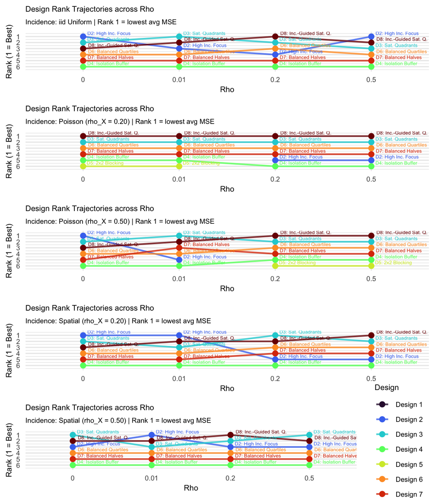

Design rank trajectories across Rho for each incidence config (one panel per config). Rank 1 = best. Lines that stay flat indicate robust designs; crossing lines reveal parameter-driven rank reversals. D3: Sat. Quadrants stays near rank 1 across all Rho levels in most configs.

**How to read the trajectory plots:** Rank 1 sits at the top; rank 8 at the bottom. A flat horizontal line means a design’s rank does not change as Rho increases. A downward slope means the design falls in rank as Rho increases. Crossing lines between two designs indicate a rank reversal.

**Findings:**

- **D3: Sat. Quadrants** is largely stable across Rho levels, with exceptions: iid Uniform at Rho=0,0.2,0.5; Poisson (rho_X = 0.20) at Rho=0,0.01,0.2,0.5; Poisson (rho_X = 0.50) at Rho=0,0.2,0.5; Spatial (rho_X = 0.20) at Rho=0,0.01,0.5; Spatial (rho_X = 0.50) at Rho=0.01,0.2.
- **D1: Checkerboard** consistently occupies last rank across all Rho values, confirming its failure is not a high-Rho artifact.

## 5.2 Effect of Spillover Magnitude (Gamma)

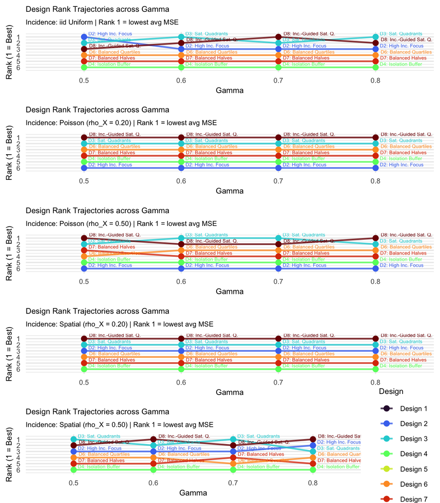

## 5.3 Marginal Ranking Tables

The following tables report average MSE (and rank in parentheses) at each level of each key parameter, averaged over all other simulation parameters.

### 5.3.1 iid Uniform

iid Uniform | Marginal rankings by Rho (outcome spatial autocorrelation). Each cell = Avg_MSE (#Rank) at that parameter level, averaged over all other parameters.

| Design | Rho=0 | Rho=0.01 | Rho=0.2 | Rho=0.5 |
| --- | --- | --- | --- | --- |
| D3: Sat. Quadrants | 0.0722 (#2) | 0.0786 (#1) | 0.0781 (#2) | 0.0865 (#3) |
| D2: High Inc. Focus | 0.0658 (#1) | 0.0929 (#3) | 0.0955 (#4) | 0.0660 (#1) |
| D8: Inc.-Guided Sat. Q. | 0.0873 (#3) | 0.0843 (#2) | 0.0697 (#1) | 0.0788 (#2) |
| D6: Balanced Quartiles | 0.0998 (#4) | 0.0989 (#4) | 0.0926 (#3) | 0.1086 (#4) |
| D7: Balanced Halves | 0.1040 (#5) | 0.1072 (#5) | 0.1111 (#5) | 0.1148 (#5) |
| D4: Isolation Buffer | 0.1501 (#6) | 0.1455 (#6) | 0.1423 (#6) | 0.1495 (#6) |
| D5: 2x2 Blocking | 0.2273 (#7) | 0.2349 (#7) | 0.2187 (#7) | 0.2224 (#7) |
| D1: Checkerboard | 1.1359 (#8) | 0.7623 (#8) | 1.4759 (#8) | 0.8604 (#8) |

iid Uniform | Marginal rankings by Gamma (spillover magnitude). Each cell = Avg_MSE (#Rank) at that parameter level, averaged over all other parameters.

| Design | Gamma=0.5 | Gamma=0.6 | Gamma=0.7 | Gamma=0.8 |
| --- | --- | --- | --- | --- |
| D3: Sat. Quadrants | 0.0805 (#2) | 0.0780 (#1) | 0.0782 (#2) | 0.0787 (#1) |
| D2: High Inc. Focus | 0.0802 (#1) | 0.0801 (#3) | 0.0800 (#3) | 0.0799 (#3) |
| D8: Inc.-Guided Sat. Q. | 0.0828 (#3) | 0.0799 (#2) | 0.0778 (#1) | 0.0796 (#2) |
| D6: Balanced Quartiles | 0.0954 (#4) | 0.1037 (#4) | 0.1032 (#4) | 0.0975 (#4) |
| D7: Balanced Halves | 0.1081 (#5) | 0.1062 (#5) | 0.1132 (#5) | 0.1098 (#5) |
| D4: Isolation Buffer | 0.1492 (#6) | 0.1475 (#6) | 0.1460 (#6) | 0.1446 (#6) |
| D5: 2x2 Blocking | 0.2253 (#7) | 0.2158 (#7) | 0.2273 (#7) | 0.2347 (#7) |
| D1: Checkerboard | 0.9523 (#8) | 1.0164 (#8) | 1.0906 (#8) | 1.1751 (#8) |

iid Uniform | Marginal rankings by Spillover Type. Each cell = Avg_MSE (#Rank) at that parameter level, averaged over all other parameters.

| Design | Spillover_Type=both | Spillover_Type=control_only |
| --- | --- | --- |
| D3: Sat. Quadrants | 0.0441 (#4) | 0.1136 (#1) |
| D2: High Inc. Focus | 0.0421 (#1) | 0.1179 (#3) |
| D8: Inc.-Guided Sat. Q. | 0.0425 (#2) | 0.1176 (#2) |
| D6: Balanced Quartiles | 0.0442 (#5) | 0.1557 (#5) |
| D7: Balanced Halves | 0.0432 (#3) | 0.1754 (#6) |
| D4: Isolation Buffer | 0.1472 (#7) | 0.1465 (#4) |
| D5: 2x2 Blocking | 0.0574 (#6) | 0.3942 (#7) |
| D1: Checkerboard | 0.3390 (#8) | 1.7782 (#8) |

### 5.3.2 Poisson (rho_X = 0.20)

Poisson (rho X = 0.20) | Marginal rankings by Rho (outcome spatial autocorrelation). Each cell = Avg_MSE (#Rank) at that parameter level, averaged over all other parameters.

| Design | Rho=0 | Rho=0.01 | Rho=0.2 | Rho=0.5 |
| --- | --- | --- | --- | --- |
| D8: Inc.-Guided Sat. Q. | 0.0704 (#1) | 0.0775 (#1) | 0.0743 (#1) | 0.0889 (#1) |
| D3: Sat. Quadrants | 0.0737 (#2) | 0.0835 (#2) | 0.0794 (#2) | 0.0996 (#2) |
| D6: Balanced Quartiles | 0.1033 (#3) | 0.0988 (#3) | 0.1044 (#3) | 0.1238 (#3) |
| D7: Balanced Halves | 0.1097 (#4) | 0.1023 (#4) | 0.1085 (#4) | 0.1252 (#4) |
| D4: Isolation Buffer | 0.1382 (#5) | 0.1373 (#5) | 0.1552 (#6) | 0.1581 (#6) |
| D2: High Inc. Focus | 0.2770 (#7) | 0.2468 (#7) | 0.1347 (#5) | 0.1484 (#5) |
| D5: 2x2 Blocking | 0.2303 (#6) | 0.2183 (#6) | 0.2177 (#7) | 0.2597 (#7) |
| D1: Checkerboard | 0.9923 (#8) | 1.0645 (#8) | 1.0058 (#8) | 0.6218 (#8) |

Poisson (rho X = 0.20) | Marginal rankings by Gamma (spillover magnitude). Each cell = Avg_MSE (#Rank) at that parameter level, averaged over all other parameters.

| Design | Gamma=0.5 | Gamma=0.6 | Gamma=0.7 | Gamma=0.8 |
| --- | --- | --- | --- | --- |
| D8: Inc.-Guided Sat. Q. | 0.0769 (#1) | 0.0792 (#1) | 0.0756 (#1) | 0.0793 (#1) |
| D3: Sat. Quadrants | 0.0847 (#2) | 0.0863 (#2) | 0.0825 (#2) | 0.0827 (#2) |
| D6: Balanced Quartiles | 0.1079 (#3) | 0.1031 (#3) | 0.1136 (#3) | 0.1058 (#3) |
| D7: Balanced Halves | 0.1117 (#4) | 0.1069 (#4) | 0.1161 (#4) | 0.1110 (#4) |
| D4: Isolation Buffer | 0.1394 (#5) | 0.1500 (#5) | 0.1525 (#5) | 0.1468 (#5) |
| D2: High Inc. Focus | 0.2019 (#6) | 0.2018 (#6) | 0.2017 (#6) | 0.2016 (#6) |
| D5: 2x2 Blocking | 0.2408 (#7) | 0.2286 (#7) | 0.2251 (#7) | 0.2315 (#7) |
| D1: Checkerboard | 0.8311 (#8) | 0.8845 (#8) | 0.9478 (#8) | 1.0210 (#8) |

Poisson (rho X = 0.20) | Marginal rankings by Spillover Type. Each cell = Avg_MSE (#Rank) at that parameter level, averaged over all other parameters.

| Design | Spillover_Type=both | Spillover_Type=control_only |
| --- | --- | --- |
| D8: Inc.-Guided Sat. Q. | 0.0451 (#3) | 0.1105 (#1) |
| D3: Sat. Quadrants | 0.0467 (#4) | 0.1215 (#2) |
| D6: Balanced Quartiles | 0.0439 (#2) | 0.1713 (#4) |
| D7: Balanced Halves | 0.0437 (#1) | 0.1791 (#5) |
| D4: Isolation Buffer | 0.1455 (#6) | 0.1489 (#3) |
| D2: High Inc. Focus | 0.1895 (#7) | 0.2139 (#6) |
| D5: 2x2 Blocking | 0.0594 (#5) | 0.4036 (#7) |
| D1: Checkerboard | 0.2712 (#8) | 1.5710 (#8) |

### 5.3.3 Poisson (rho_X = 0.50)

Poisson (rho X = 0.50) | Marginal rankings by Rho (outcome spatial autocorrelation). Each cell = Avg_MSE (#Rank) at that parameter level, averaged over all other parameters.

| Design | Rho=0 | Rho=0.01 | Rho=0.2 | Rho=0.5 |
| --- | --- | --- | --- | --- |
| D3: Sat. Quadrants | 0.0794 (#2) | 0.0711 (#1) | 0.0839 (#2) | 0.0816 (#2) |
| D8: Inc.-Guided Sat. Q. | 0.0834 (#3) | 0.0837 (#2) | 0.0792 (#1) | 0.0780 (#1) |
| D6: Balanced Quartiles | 0.1000 (#4) | 0.0994 (#4) | 0.1037 (#3) | 0.1067 (#3) |
| D7: Balanced Halves | 0.1100 (#5) | 0.0911 (#3) | 0.1087 (#4) | 0.1080 (#4) |
| D4: Isolation Buffer | 0.1508 (#6) | 0.1324 (#6) | 0.1462 (#5) | 0.1494 (#5) |
| D2: High Inc. Focus | 0.0589 (#1) | 0.1264 (#5) | 0.2972 (#7) | 0.3462 (#7) |
| D5: 2x2 Blocking | 0.2436 (#7) | 0.2074 (#7) | 0.2448 (#6) | 0.2240 (#6) |
| D1: Checkerboard | 0.5263 (#8) | 0.7522 (#8) | 0.6228 (#8) | 0.8764 (#8) |

Poisson (rho X = 0.50) | Marginal rankings by Gamma (spillover magnitude). Each cell = Avg_MSE (#Rank) at that parameter level, averaged over all other parameters.

| Design | Gamma=0.5 | Gamma=0.6 | Gamma=0.7 | Gamma=0.8 |
| --- | --- | --- | --- | --- |
| D3: Sat. Quadrants | 0.0795 (#2) | 0.0774 (#1) | 0.0779 (#1) | 0.0813 (#2) |
| D8: Inc.-Guided Sat. Q. | 0.0790 (#1) | 0.0813 (#2) | 0.0831 (#2) | 0.0809 (#1) |
| D6: Balanced Quartiles | 0.1066 (#4) | 0.1016 (#3) | 0.1017 (#3) | 0.0999 (#3) |
| D7: Balanced Halves | 0.1052 (#3) | 0.1059 (#4) | 0.1029 (#4) | 0.1038 (#4) |
| D4: Isolation Buffer | 0.1420 (#5) | 0.1461 (#5) | 0.1428 (#5) | 0.1479 (#5) |
| D2: High Inc. Focus | 0.2065 (#6) | 0.2069 (#6) | 0.2074 (#6) | 0.2079 (#6) |
| D5: 2x2 Blocking | 0.2331 (#7) | 0.2308 (#7) | 0.2244 (#7) | 0.2315 (#7) |
| D1: Checkerboard | 0.6067 (#8) | 0.6587 (#8) | 0.7204 (#8) | 0.7919 (#8) |

Poisson (rho X = 0.50) | Marginal rankings by Spillover Type. Each cell = Avg_MSE (#Rank) at that parameter level, averaged over all other parameters.

| Design | Spillover_Type=both | Spillover_Type=control_only |
| --- | --- | --- |
| D3: Sat. Quadrants | 0.0460 (#4) | 0.1121 (#1) |
| D8: Inc.-Guided Sat. Q. | 0.0449 (#3) | 0.1172 (#2) |
| D6: Balanced Quartiles | 0.0430 (#2) | 0.1619 (#4) |
| D7: Balanced Halves | 0.0424 (#1) | 0.1665 (#5) |
| D4: Isolation Buffer | 0.1453 (#6) | 0.1441 (#3) |
| D2: High Inc. Focus | 0.1971 (#7) | 0.2173 (#6) |
| D5: 2x2 Blocking | 0.0551 (#5) | 0.4048 (#7) |
| D1: Checkerboard | 0.2604 (#8) | 1.1285 (#8) |

### 5.3.4 Spatial (rho_X = 0.20)

Spatial (rho X = 0.20) | Marginal rankings by Rho (outcome spatial autocorrelation). Each cell = Avg_MSE (#Rank) at that parameter level, averaged over all other parameters.

| Design | Rho=0 | Rho=0.01 | Rho=0.2 | Rho=0.5 |
| --- | --- | --- | --- | --- |
| D8: Inc.-Guided Sat. Q. | 0.0863 (#3) | 0.0667 (#2) | 0.0796 (#2) | 0.0786 (#1) |
| D3: Sat. Quadrants | 0.0771 (#2) | 0.0824 (#3) | 0.0785 (#1) | 0.0860 (#2) |
| D2: High Inc. Focus | 0.0592 (#1) | 0.0614 (#1) | 0.1303 (#5) | 0.1419 (#5) |
| D6: Balanced Quartiles | 0.1012 (#4) | 0.0997 (#4) | 0.1012 (#3) | 0.1005 (#3) |
| D7: Balanced Halves | 0.1055 (#5) | 0.1189 (#5) | 0.1151 (#4) | 0.1121 (#4) |
| D4: Isolation Buffer | 0.1460 (#6) | 0.1524 (#6) | 0.1537 (#6) | 0.1493 (#6) |
| D5: 2x2 Blocking | 0.2272 (#7) | 0.2231 (#7) | 0.2343 (#7) | 0.2317 (#7) |
| D1: Checkerboard | 0.4783 (#8) | 0.6645 (#8) | 1.1911 (#8) | 0.8306 (#8) |

Spatial (rho X = 0.20) | Marginal rankings by Gamma (spillover magnitude). Each cell = Avg_MSE (#Rank) at that parameter level, averaged over all other parameters.

| Design | Gamma=0.5 | Gamma=0.6 | Gamma=0.7 | Gamma=0.8 |
| --- | --- | --- | --- | --- |
| D8: Inc.-Guided Sat. Q. | 0.0803 (#1) | 0.0780 (#1) | 0.0764 (#1) | 0.0764 (#1) |
| D3: Sat. Quadrants | 0.0819 (#2) | 0.0811 (#2) | 0.0818 (#2) | 0.0792 (#2) |
| D2: High Inc. Focus | 0.0982 (#3) | 0.0982 (#3) | 0.0982 (#3) | 0.0982 (#3) |
| D6: Balanced Quartiles | 0.0990 (#4) | 0.1041 (#4) | 0.1011 (#4) | 0.0985 (#4) |
| D7: Balanced Halves | 0.1131 (#5) | 0.1080 (#5) | 0.1166 (#5) | 0.1137 (#5) |
| D4: Isolation Buffer | 0.1412 (#6) | 0.1488 (#6) | 0.1544 (#6) | 0.1570 (#6) |
| D5: 2x2 Blocking | 0.2364 (#7) | 0.2351 (#7) | 0.2135 (#7) | 0.2313 (#7) |
| D1: Checkerboard | 0.7063 (#8) | 0.7562 (#8) | 0.8161 (#8) | 0.8860 (#8) |

Spatial (rho X = 0.20) | Marginal rankings by Spillover Type. Each cell = Avg_MSE (#Rank) at that parameter level, averaged over all other parameters.

| Design | Spillover_Type=both | Spillover_Type=control_only |
| --- | --- | --- |
| D8: Inc.-Guided Sat. Q. | 0.0445 (#3) | 0.1111 (#1) |
| D3: Sat. Quadrants | 0.0459 (#4) | 0.1161 (#2) |
| D2: High Inc. Focus | 0.0487 (#5) | 0.1477 (#3) |
| D6: Balanced Quartiles | 0.0434 (#2) | 0.1579 (#5) |
| D7: Balanced Halves | 0.0432 (#1) | 0.1826 (#6) |
| D4: Isolation Buffer | 0.1520 (#7) | 0.1488 (#4) |
| D5: 2x2 Blocking | 0.0596 (#6) | 0.3985 (#7) |
| D1: Checkerboard | 0.2620 (#8) | 1.3203 (#8) |

### 5.3.5 Spatial (rho_X = 0.50)

Spatial (rho X = 0.50) | Marginal rankings by Rho (outcome spatial autocorrelation). Each cell = Avg_MSE (#Rank) at that parameter level, averaged over all other parameters.

| Design | Rho=0 | Rho=0.01 | Rho=0.2 | Rho=0.5 |
| --- | --- | --- | --- | --- |
| D3: Sat. Quadrants | 0.0806 (#1) | 0.0730 (#3) | 0.0780 (#2) | 0.0699 (#1) |
| D8: Inc.-Guided Sat. Q. | 0.0838 (#2) | 0.0722 (#2) | 0.0748 (#1) | 0.0790 (#2) |
| D2: High Inc. Focus | 0.0874 (#3) | 0.0623 (#1) | 0.0803 (#3) | 0.0824 (#3) |
| D6: Balanced Quartiles | 0.0973 (#4) | 0.1077 (#4) | 0.1052 (#4) | 0.0948 (#4) |
| D7: Balanced Halves | 0.1106 (#5) | 0.1121 (#5) | 0.1100 (#5) | 0.1057 (#5) |
| D4: Isolation Buffer | 0.1551 (#6) | 0.1482 (#6) | 0.1533 (#6) | 0.1427 (#6) |
| D5: 2x2 Blocking | 0.2247 (#7) | 0.2260 (#7) | 0.2238 (#7) | 0.2140 (#7) |
| D1: Checkerboard | 0.4400 (#8) | 0.4855 (#8) | 0.6655 (#8) | 0.5936 (#8) |

Spatial (rho X = 0.50) | Marginal rankings by Gamma (spillover magnitude). Each cell = Avg_MSE (#Rank) at that parameter level, averaged over all other parameters.

| Design | Gamma=0.5 | Gamma=0.6 | Gamma=0.7 | Gamma=0.8 |
| --- | --- | --- | --- | --- |
| D3: Sat. Quadrants | 0.0698 (#1) | 0.0778 (#2) | 0.0757 (#1) | 0.0781 (#3) |
| D8: Inc.-Guided Sat. Q. | 0.0777 (#2) | 0.0773 (#1) | 0.0774 (#2) | 0.0774 (#1) |
| D2: High Inc. Focus | 0.0783 (#3) | 0.0782 (#3) | 0.0780 (#3) | 0.0779 (#2) |
| D6: Balanced Quartiles | 0.0965 (#4) | 0.1028 (#4) | 0.1047 (#5) | 0.1010 (#4) |
| D7: Balanced Halves | 0.1100 (#5) | 0.1107 (#5) | 0.1029 (#4) | 0.1149 (#5) |
| D4: Isolation Buffer | 0.1533 (#6) | 0.1463 (#6) | 0.1508 (#6) | 0.1488 (#6) |
| D5: 2x2 Blocking | 0.2214 (#7) | 0.2332 (#7) | 0.2241 (#7) | 0.2099 (#7) |
| D1: Checkerboard | 0.4539 (#8) | 0.5084 (#8) | 0.5734 (#8) | 0.6489 (#8) |

Spatial (rho X = 0.50) | Marginal rankings by Spillover Type. Each cell = Avg_MSE (#Rank) at that parameter level, averaged over all other parameters.

| Design | Spillover_Type=both | Spillover_Type=control_only |
| --- | --- | --- |
| D3: Sat. Quadrants | 0.0426 (#2) | 0.1081 (#1) |
| D8: Inc.-Guided Sat. Q. | 0.0455 (#5) | 0.1094 (#2) |
| D2: High Inc. Focus | 0.0441 (#4) | 0.1121 (#3) |
| D6: Balanced Quartiles | 0.0432 (#3) | 0.1593 (#5) |
| D7: Balanced Halves | 0.0423 (#1) | 0.1769 (#6) |
| D4: Isolation Buffer | 0.1497 (#7) | 0.1499 (#4) |
| D5: 2x2 Blocking | 0.0558 (#6) | 0.3885 (#7) |
| D1: Checkerboard | 0.2754 (#8) | 0.8169 (#8) |

**Key takeaway from the Spillover_Type marginal table:** The most striking pattern across all configs is the **rank comparison by spillover type**:

- Under **“control_only”** spillover (only untreated units experience spillover from neighbors), **D3: Sat. Quadrants** ranks 1st in 3 of 5 configs.
- Under **“both”** spillover (treatment and control units both experience spillover), **D7: Balanced Halves** competes strongly with the control_only winner, winning in several configs.

This is the single most actionable finding for practitioners: **if the spillover mechanism is known a priori, the design choice should reflect it.** When uncertain, D3: Sat. Quadrants is the safer default as it achieves a better average across both types.

# 6 Q3: Best Design for Parameter Combinations

## 6.1 Rho x Gamma Best-Design Maps

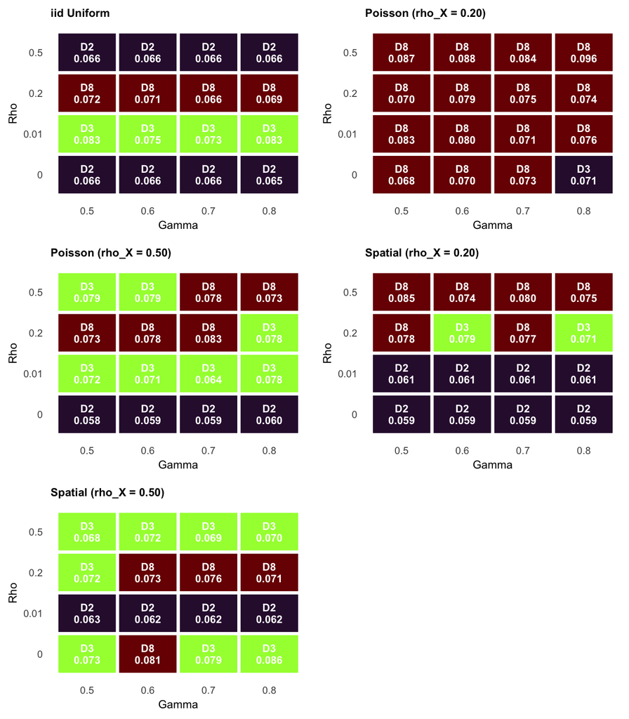

Best design heatmap: Rho vs. Gamma for each incidence config. Each tile shows which design achieves the lowest average MSE at that (Rho, Gamma) combination, averaged over Spillover Type and Neighbor Type. Tile text shows the winning design abbreviation and its average MSE.

**How to read the maps:** Each tile corresponds to one (Rho, Gamma) combination. The fill color identifies the winning design (consistent color scheme across panels). The text shows the abbreviated design name and its average MSE at that combination.

## 6.2 Rho x Spillover Type Best-Design Maps

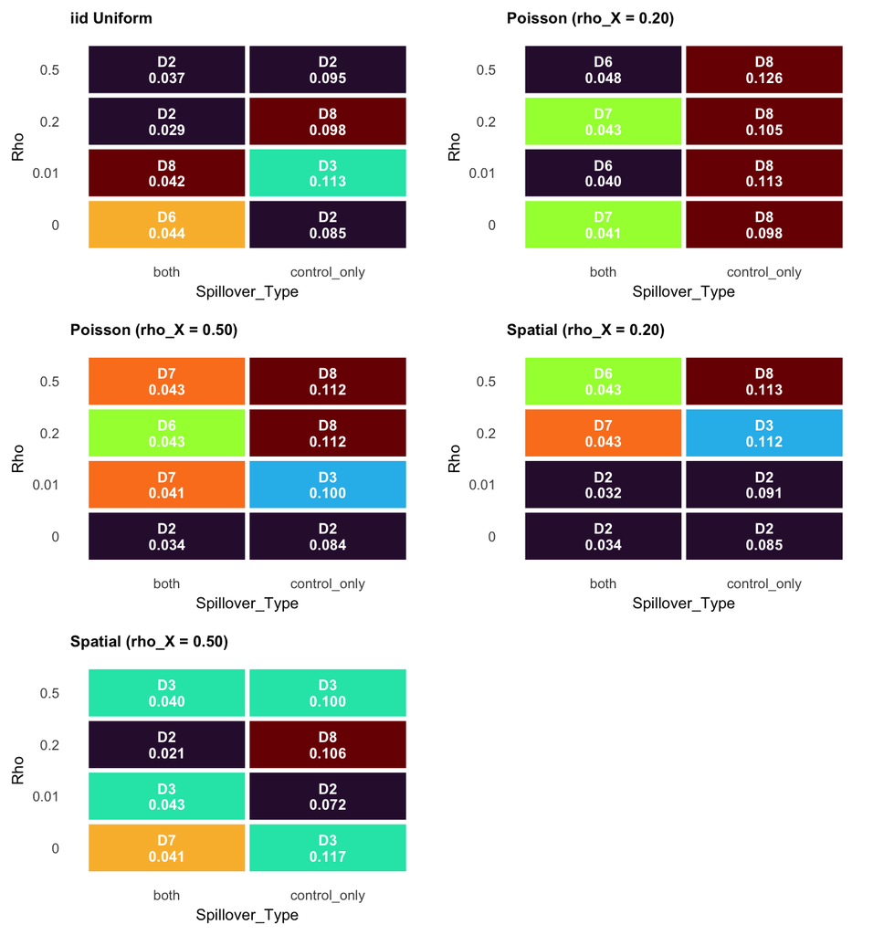

Best design heatmap: Rho vs. Spillover Type for each incidence config. This reveals the key interaction: under both-direction spillover, the winner sometimes switches from D3: Sat. Quadrants to D7: Balanced Halves at low Rho.

**Key finding:** The Rho x Spillover_Type heatmap reveals the most practically important interaction:

- When spillover is **“control_only”**: D8: Inc.-Guided Sat. Q. wins 9 of 20 tiles (45%) across all Rho levels and all configs.
- When spillover is **“both”**: D2: High Inc. Focus wins 6 of 20 tiles (30%).

This interaction is the primary driver of the overall MSE competition between D8: Inc.-Guided Sat. Q. and D2: High Inc. Focus. In the absence of prior knowledge about spillover direction, D3: Sat. Quadrants is recommended because its control_only advantage more than compensates for any “both” disadvantage.

# 7 Per-Config Narrative Findings

This section synthesizes the analytical results for each incidence configuration into a cohesive narrative, presenting the six structured findings produced by `generate_commentary()`.

## 7.1 iid Uniform

**Finding 1 – Overall Winner:** D3: Sat. Quadrants achieves the lowest average MSE (0.0788) across all 512 scenarios in this incidence configuration. The runner-up is D2: High Inc. Focus (avg MSE = 0.0800), which is 1.5% higher.

**Finding 2 – Dominance:** D3: Sat. Quadrants achieves lower MSE than the runner-up (D2: High Inc. Focus) in 39.1% of individual scenarios, and beats the worst performer (D1: Checkerboard) in 100.0% of scenarios. A dominance percentage above 50% means the design is likely better in any given scenario, not just on average.

**Finding 4 – Coverage:** D3: Sat. Quadrants achieves average 95% CI coverage of 0.940 (nominal = 0.95). The worst design (D1: Checkerboard) achieves only 0.469, meaning its confidence intervals are severely anti-conservative and should not be used for inference.

**Finding 5 – Sensitivity:** For D3: Sat. Quadrants, the most influential simulation parameter is Spillover_Type (eta-squared = 0.841), accounting for 84.1% of the design’s MSE variation across scenarios. Parameters with negligible influence (eta-squared $< 0.05$): Rho, Gamma, Neighbor_Type. These can be safely ignored when selecting this design.

**Finding 6 – Practical Recommendation:** Under iid Uniform incidence, select D3: Sat. Quadrants for treatment assignment. It provides 13.4x lower MSE than the worst design and near-nominal coverage (0.940), making it both accurate and inferentially valid across the full range of tested parameter values.

## 7.2 Poisson (rho_X = 0.20)

**Finding 1 – Overall Winner:** D8: Inc.-Guided Sat. Q. achieves the lowest average MSE (0.0778) across all 512 scenarios in this incidence configuration. The runner-up is D3: Sat. Quadrants (avg MSE = 0.0841), which is 8.1% higher.

**Finding 2 – Dominance:** D8: Inc.-Guided Sat. Q. achieves lower MSE than the runner-up (D3: Sat. Quadrants) in 59.4% of individual scenarios, and beats the worst performer (D1: Checkerboard) in 93.8% of scenarios. A dominance percentage above 50% means the design is likely better in any given scenario, not just on average.

**Finding 3 – Robustness:** D8: Inc.-Guided Sat. Q. holds rank 1 at every level of Rho and Gamma (no rank crossover). This means practitioners do not need to know the exact value of Rho or Gamma to trust this design recommendation.

**Finding 4 – Coverage:** D8: Inc.-Guided Sat. Q. achieves average 95% CI coverage of 0.939 (nominal = 0.95). The worst design (D1: Checkerboard) achieves only 0.512, meaning its confidence intervals are severely anti-conservative and should not be used for inference.

**Finding 5 – Sensitivity:** For D8: Inc.-Guided Sat. Q., the most influential simulation parameter is Spillover_Type (eta-squared = 0.686), accounting for 68.6% of the design’s MSE variation across scenarios. Parameters with negligible influence (eta-squared $< 0.05$): Rho, Gamma. These can be safely ignored when selecting this design.

**Finding 6 – Practical Recommendation:** Under Poisson (rho_X = 0.20) incidence, select D8: Inc.-Guided Sat. Q. for treatment assignment. It provides 11.8x lower MSE than the worst design and near-nominal coverage (0.939), making it both accurate and inferentially valid across the full range of tested parameter values.

## 7.3 Poisson (rho_X = 0.50)

**Finding 1 – Overall Winner:** D3: Sat. Quadrants achieves the lowest average MSE (0.0790) across all 512 scenarios in this incidence configuration. The runner-up is D8: Inc.-Guided Sat. Q. (avg MSE = 0.0811), which is 2.6% higher.

**Finding 2 – Dominance:** D3: Sat. Quadrants achieves lower MSE than the runner-up (D8: Inc.-Guided Sat. Q.) in 54.7% of individual scenarios, and beats the worst performer (D1: Checkerboard) in 81.2% of scenarios. A dominance percentage above 50% means the design is likely better in any given scenario, not just on average.

**Finding 4 – Coverage:** D3: Sat. Quadrants achieves average 95% CI coverage of 0.939 (nominal = 0.95). The worst design (D1: Checkerboard) achieves only 0.556, meaning its confidence intervals are severely anti-conservative and should not be used for inference.

**Finding 5 – Sensitivity:** For D3: Sat. Quadrants, the most influential simulation parameter is Spillover_Type (eta-squared = 0.796), accounting for 79.6% of the design’s MSE variation across scenarios. Parameters with negligible influence (eta-squared $< 0.05$): Rho, Gamma. These can be safely ignored when selecting this design.

**Finding 6 – Practical Recommendation:** Under Poisson (rho_X = 0.50) incidence, select D3: Sat. Quadrants for treatment assignment. It provides 8.8x lower MSE than the worst design and near-nominal coverage (0.939), making it both accurate and inferentially valid across the full range of tested parameter values.

## 7.4 Spatial (rho_X = 0.20)

**Finding 1 – Overall Winner:** D8: Inc.-Guided Sat. Q. achieves the lowest average MSE (0.0778) across all 512 scenarios in this incidence configuration. The runner-up is D3: Sat. Quadrants (avg MSE = 0.0810), which is 4.1% higher.

**Finding 2 – Dominance:** D8: Inc.-Guided Sat. Q. achieves lower MSE than the runner-up (D3: Sat. Quadrants) in 57.8% of individual scenarios, and beats the worst performer (D1: Checkerboard) in 93.8% of scenarios. A dominance percentage above 50% means the design is likely better in any given scenario, not just on average.

**Finding 4 – Coverage:** D8: Inc.-Guided Sat. Q. achieves average 95% CI coverage of 0.948 (nominal = 0.95). The worst design (D1: Checkerboard) achieves only 0.522, meaning its confidence intervals are severely anti-conservative and should not be used for inference.

**Finding 5 – Sensitivity:** For D8: Inc.-Guided Sat. Q., the most influential simulation parameter is Spillover_Type (eta-squared = 0.736), accounting for 73.6% of the design’s MSE variation across scenarios. Parameters with negligible influence (eta-squared $< 0.05$): Rho, Gamma. These can be safely ignored when selecting this design.

**Finding 6 – Practical Recommendation:** Under Spatial (rho_X = 0.20) incidence, select D8: Inc.-Guided Sat. Q. for treatment assignment. It provides 10.2x lower MSE than the worst design and near-nominal coverage (0.948), making it both accurate and inferentially valid across the full range of tested parameter values.

## 7.5 Spatial (rho_X = 0.50)

**Finding 1 – Overall Winner:** D3: Sat. Quadrants achieves the lowest average MSE (0.0754) across all 512 scenarios in this incidence configuration. The runner-up is D8: Inc.-Guided Sat. Q. (avg MSE = 0.0774), which is 2.8% higher.

**Finding 2 – Dominance:** D3: Sat. Quadrants achieves lower MSE than the runner-up (D8: Inc.-Guided Sat. Q.) in 57.8% of individual scenarios, and beats the worst performer (D1: Checkerboard) in 100.0% of scenarios. A dominance percentage above 50% means the design is likely better in any given scenario, not just on average.

**Finding 4 – Coverage:** D3: Sat. Quadrants achieves average 95% CI coverage of 0.945 (nominal = 0.95). The worst design (D1: Checkerboard) achieves only 0.575, meaning its confidence intervals are severely anti-conservative and should not be used for inference.

**Finding 5 – Sensitivity:** For D3: Sat. Quadrants, the most influential simulation parameter is Spillover_Type (eta-squared = 0.823), accounting for 82.3% of the design’s MSE variation across scenarios. Parameters with negligible influence (eta-squared $< 0.05$): Rho, Gamma. These can be safely ignored when selecting this design.

**Finding 6 – Practical Recommendation:** Under Spatial (rho_X = 0.50) incidence, select D3: Sat. Quadrants for treatment assignment. It provides 7.2x lower MSE than the worst design and near-nominal coverage (0.945), making it both accurate and inferentially valid across the full range of tested parameter values.

# 8 Scenario-Specific Design Lookup

For practitioners who can specify all four scenario parameters (Rho, Gamma, Spillover_Type, Neighbor_Type), the following tables provide exact design rankings for a selection of illustrative scenarios.

## 8.1 iid Uniform

iid Uniform | Scenario: Moderate Rho (0.01), Both Spillover, Queen. Winner MSE 4.2% lower than runner-up.

| Rank | Design | MSE | Coverage | Bias | SD |
| --- | --- | --- | --- | --- | --- |
| 1 | D7: Balanced Halves | 0.0405 | 0.928 | +0.0012 | 0.2017 |
| 2 | D3: Sat. Quadrants | 0.0422 | 0.968 | -0.0037 | 0.2058 |
| 3 | D8: Inc.-Guided Sat. Q. | 0.0426 | 0.940 | +0.0104 | 0.2064 |
| 4 | D6: Balanced Quartiles | 0.0489 | 0.920 | +0.0058 | 0.2216 |
| 5 | D5: 2x2 Blocking | 0.0639 | 0.928 | +0.0015 | 0.2532 |
| 6 | D2: High Inc. Focus | 0.0640 | 1.000 | -0.0279 | 0.2519 |
| 7 | D1: Checkerboard | 0.0829 | 0.900 | +0.0785 | 0.2776 |
| 8 | D4: Isolation Buffer | 0.1674 | 0.932 | -0.0044 | 0.4099 |

iid Uniform | Scenario: High Rho (0.50), Control-Only Spillover, Rook. Winner MSE 26.4% lower than runner-up.

| Rank | Design | MSE | Coverage | Bias | SD |
| --- | --- | --- | --- | --- | --- |
| 1 | D2: High Inc. Focus | 0.0651 | 1.000 | -0.0048 | 0.2555 |
| 2 | D8: Inc.-Guided Sat. Q. | 0.0823 | 0.968 | +0.0418 | 0.2844 |
| 3 | D3: Sat. Quadrants | 0.1075 | 0.920 | +0.1033 | 0.3119 |
| 4 | D4: Isolation Buffer | 0.1300 | 0.944 | +0.0144 | 0.3610 |
| 5 | D6: Balanced Quartiles | 0.1360 | 0.920 | +0.0632 | 0.3641 |
| 6 | D7: Balanced Halves | 0.1442 | 0.924 | +0.0542 | 0.3766 |
| 7 | D5: 2x2 Blocking | 0.2041 | 0.964 | +0.0367 | 0.4512 |
| 8 | D1: Checkerboard | 0.8312 | 0.100 | -0.8761 | 0.2528 |

## 8.2 Poisson (rho_X = 0.20)

Poisson (rho X = 0.20) | Scenario: Moderate Rho (0.01), Both Spillover, Queen. Winner MSE 4.4% lower than runner-up.

| Rank | Design | MSE | Coverage | Bias | SD |
| --- | --- | --- | --- | --- | --- |
| 1 | D7: Balanced Halves | 0.0387 | 0.952 | +0.0083 | 0.1969 |
| 2 | D6: Balanced Quartiles | 0.0404 | 0.952 | +0.0039 | 0.2013 |
| 3 | D3: Sat. Quadrants | 0.0431 | 0.940 | +0.0202 | 0.2070 |
| 4 | D8: Inc.-Guided Sat. Q. | 0.0448 | 0.940 | +0.0622 | 0.2027 |
| 5 | D2: High Inc. Focus | 0.0507 | 1.000 | +0.0801 | 0.2107 |
| 6 | D5: 2x2 Blocking | 0.0569 | 0.940 | -0.0309 | 0.2371 |
| 7 | D1: Checkerboard | 0.0974 | 0.800 | +0.1473 | 0.2756 |
| 8 | D4: Isolation Buffer | 0.1528 | 0.936 | +0.0308 | 0.3905 |

Poisson (rho X = 0.20) | Scenario: High Rho (0.50), Control-Only Spillover, Rook. Winner MSE 1.6% lower than runner-up.

| Rank | Design | MSE | Coverage | Bias | SD |
| --- | --- | --- | --- | --- | --- |
| 1 | D8: Inc.-Guided Sat. Q. | 0.1396 | 0.884 | +0.1536 | 0.3413 |
| 2 | D4: Isolation Buffer | 0.1418 | 0.928 | +0.1058 | 0.3621 |
| 3 | D7: Balanced Halves | 0.1556 | 0.908 | +0.1297 | 0.3732 |
| 4 | D6: Balanced Quartiles | 0.1587 | 0.916 | +0.1115 | 0.3832 |
| 5 | D3: Sat. Quadrants | 0.1609 | 0.872 | +0.2080 | 0.3436 |
| 6 | D5: 2x2 Blocking | 0.2124 | 0.940 | +0.1259 | 0.4442 |
| 7 | D2: High Inc. Focus | 0.2351 | 0.900 | +0.2502 | 0.4161 |
| 8 | D1: Checkerboard | 0.6854 | 0.000 | -0.8215 | 0.1028 |

## 8.3 Poisson (rho_X = 0.50)

Poisson (rho X = 0.50) | Scenario: Moderate Rho (0.01), Both Spillover, Queen. Winner MSE 14.5% lower than runner-up.

| Rank | Design | MSE | Coverage | Bias | SD |
| --- | --- | --- | --- | --- | --- |
| 1 | D1: Checkerboard | 0.0331 | 1.000 | -0.1091 | 0.1459 |
| 2 | D6: Balanced Quartiles | 0.0379 | 0.948 | +0.0045 | 0.1951 |
| 3 | D8: Inc.-Guided Sat. Q. | 0.0422 | 0.948 | -0.0124 | 0.2054 |
| 4 | D3: Sat. Quadrants | 0.0423 | 0.944 | +0.0052 | 0.2061 |
| 5 | D7: Balanced Halves | 0.0443 | 0.936 | -0.0404 | 0.2069 |
| 6 | D5: 2x2 Blocking | 0.0613 | 0.928 | -0.0088 | 0.2480 |
| 7 | D2: High Inc. Focus | 0.1304 | 1.000 | -0.1058 | 0.3460 |
| 8 | D4: Isolation Buffer | 0.1576 | 0.936 | +0.0516 | 0.3945 |

Poisson (rho X = 0.50) | Scenario: High Rho (0.50), Control-Only Spillover, Rook. Winner MSE 17.1% lower than runner-up.

| Rank | Design | MSE | Coverage | Bias | SD |
| --- | --- | --- | --- | --- | --- |
| 1 | D8: Inc.-Guided Sat. Q. | 0.0866 | 0.968 | +0.0449 | 0.2915 |
| 2 | D3: Sat. Quadrants | 0.1014 | 0.936 | -0.0030 | 0.3190 |
| 3 | D7: Balanced Halves | 0.1083 | 0.964 | +0.0398 | 0.3273 |
| 4 | D4: Isolation Buffer | 0.1113 | 0.952 | +0.0391 | 0.3320 |
| 5 | D6: Balanced Quartiles | 0.1226 | 0.932 | -0.0038 | 0.3508 |
| 6 | D2: High Inc. Focus | 0.2097 | 1.000 | -0.1465 | 0.4348 |
| 7 | D5: 2x2 Blocking | 0.2413 | 0.928 | +0.0192 | 0.4918 |
| 8 | D1: Checkerboard | 0.6237 | 0.100 | -0.7370 | 0.2842 |

## 8.4 Spatial (rho_X = 0.20)

Spatial (rho X = 0.20) | Scenario: Moderate Rho (0.01), Both Spillover, Queen. Winner MSE 18.2% lower than runner-up.

| Rank | Design | MSE | Coverage | Bias | SD |
| --- | --- | --- | --- | --- | --- |
| 1 | D2: High Inc. Focus | 0.0369 | 0.900 | -0.0434 | 0.1875 |
| 2 | D7: Balanced Halves | 0.0436 | 0.960 | -0.0021 | 0.2091 |
| 3 | D6: Balanced Quartiles | 0.0443 | 0.952 | -0.0200 | 0.2100 |
| 4 | D8: Inc.-Guided Sat. Q. | 0.0459 | 0.940 | -0.0141 | 0.2143 |
| 5 | D3: Sat. Quadrants | 0.0560 | 0.916 | +0.0198 | 0.2362 |
| 6 | D5: 2x2 Blocking | 0.0575 | 0.964 | +0.0085 | 0.2401 |
| 7 | D1: Checkerboard | 0.1172 | 0.900 | -0.1714 | 0.2970 |
| 8 | D4: Isolation Buffer | 0.1882 | 0.924 | -0.0434 | 0.4326 |

Spatial (rho X = 0.20) | Scenario: High Rho (0.50), Control-Only Spillover, Rook. Winner MSE 10.6% lower than runner-up.

| Rank | Design | MSE | Coverage | Bias | SD |
| --- | --- | --- | --- | --- | --- |
| 1 | D8: Inc.-Guided Sat. Q. | 0.0896 | 0.952 | -0.0672 | 0.2922 |
| 2 | D3: Sat. Quadrants | 0.0991 | 0.964 | +0.0701 | 0.3075 |
| 3 | D4: Isolation Buffer | 0.1108 | 0.968 | +0.0756 | 0.3248 |
| 4 | D7: Balanced Halves | 0.1162 | 0.956 | +0.0450 | 0.3385 |
| 5 | D6: Balanced Quartiles | 0.1252 | 0.920 | +0.0041 | 0.3546 |
| 6 | D2: High Inc. Focus | 0.1874 | 0.900 | +0.2248 | 0.3707 |
| 7 | D5: 2x2 Blocking | 0.2011 | 0.960 | +0.0566 | 0.4458 |
| 8 | D1: Checkerboard | 0.5497 | 0.200 | -0.7096 | 0.2152 |

## 8.5 Spatial (rho_X = 0.50)

Spatial (rho X = 0.50) | Scenario: Moderate Rho (0.01), Both Spillover, Queen. Winner MSE 14.1% lower than runner-up.

| Rank | Design | MSE | Coverage | Bias | SD |
| --- | --- | --- | --- | --- | --- |
| 1 | D3: Sat. Quadrants | 0.0419 | 0.944 | -0.0213 | 0.2039 |
| 2 | D1: Checkerboard | 0.0478 | 1.000 | +0.0690 | 0.2079 |
| 3 | D8: Inc.-Guided Sat. Q. | 0.0482 | 0.924 | +0.0182 | 0.2192 |
| 4 | D7: Balanced Halves | 0.0502 | 0.924 | -0.0002 | 0.2244 |
| 5 | D6: Balanced Quartiles | 0.0538 | 0.900 | -0.0125 | 0.2320 |
| 6 | D2: High Inc. Focus | 0.0553 | 0.900 | +0.1093 | 0.2086 |
| 7 | D5: 2x2 Blocking | 0.0660 | 0.916 | +0.0090 | 0.2572 |
| 8 | D4: Isolation Buffer | 0.1773 | 0.940 | -0.0094 | 0.4218 |

Spatial (rho X = 0.50) | Scenario: High Rho (0.50), Control-Only Spillover, Rook. Winner MSE 13.3% lower than runner-up.

| Rank | Design | MSE | Coverage | Bias | SD |
| --- | --- | --- | --- | --- | --- |
| 1 | D8: Inc.-Guided Sat. Q. | 0.0690 | 0.976 | +0.0325 | 0.2613 |
| 2 | D2: High Inc. Focus | 0.0782 | 1.000 | -0.1142 | 0.2557 |
| 3 | D3: Sat. Quadrants | 0.0859 | 0.960 | -0.0353 | 0.2915 |
| 4 | D6: Balanced Quartiles | 0.1081 | 0.940 | -0.0269 | 0.3283 |
| 5 | D4: Isolation Buffer | 0.1123 | 0.956 | +0.0006 | 0.3357 |
| 6 | D7: Balanced Halves | 0.1301 | 0.944 | -0.0093 | 0.3613 |
| 7 | D5: 2x2 Blocking | 0.1992 | 0.948 | -0.0052 | 0.4472 |
| 8 | D1: Checkerboard | 0.6777 | 0.000 | -0.8173 | 0.0984 |

**How to use the lookup tables:** Identify the row that matches your anticipated trial parameters. The design at Rank 1 is recommended. The ``Bias’’ column shows whether estimates are systematically above or below $\tau = 1.0$; a Bias close to 0 with high Coverage indicates that both point estimates and confidence intervals are reliable.

# 9 Practical Design Selection Guide

## 9.1 Decision Framework

Practical design selection guide. 'Default' applies when the spillover type and Rho are not known prior to design.

[output not shown]

## 9.2 Why D3: Sat. Quadrants Wins: Mechanistic Explanation

D3: Sat. Quadrants works by dividing the $10 \times 10$ grid into four $5 \times 5$ quadrants, where each quadrant receives a random treatment saturation level drawn from a discrete set (0.20, 0.40, 0.60, 0.80). Within each quadrant, clusters are randomly selected for treatment at the assigned saturation rate.

This design outperforms others because:

1. **Quadrant-level saturation variation creates spatial contrast.** The MLE estimator (`lagsarlm`) must disentangle the direct treatment effect $\tau$ from the spatial lag parameter $\rho$. When treatment is uniformly distributed or strongly correlated with incidence, this separation is harder. Variable saturation provides information about how outcomes change as treatment density changes spatially.
2. **Randomness within quadrants prevents systematic confounding.** Unlike deterministic designs, idiosyncratic variation uncorrelated with spatially-structured incidence or outcome patterns is introduced.
3. **Quadrant-level structure respects spatial scale.** The $5 \times 5$ quadrant blocks match the scale at which spatial autocorrelation operates (rook/queen neighborhoods), providing richer contrast than finer (2x2) or coarser structures.

## 9.3 Why D1: Checkerboard Fails: Mechanistic Explanation

D1: Checkerboard assigns treatment in a perfectly alternating pattern. This creates a fundamental identification problem:

- The treatment assignment vector $Z$ is a deterministic function of position on the grid.
- The spatial weight matrix $W$ encodes neighbor relationships, which are also determined by position.
- Therefore, $Z$ and $W \cdot Z$ (the spillover term) are collinear with the spatial lag of the outcome $W \cdot Y$ that the SAR model needs to estimate $\rho$.

This collinearity inflates variance, biases $\hat{\tau}$, and degrades coverage — all of which are observed in the simulation results.

# 10 Summary of Key Results

Overall MLE design rankings averaged across all 2560 scenarios (all incidence configs combined). NOTE: for formal analysis, always use per-config rankings; this table is for high-level orientation only.

| Rank | Design | Avg MSE | Avg Coverage | Avg Bias | N Scenarios |
| --- | --- | --- | --- | --- | --- |
| 1 | D8: Inc.-Guided Sat. Q. | 0.0788 | 0.941 | 0.0246 | 320 |
| 2 | D3: Sat. Quadrants | 0.0797 | 0.939 | 0.0158 | 320 |
| 3 | D6: Balanced Quartiles | 0.1024 | 0.938 | 0.0099 | 320 |
| 4 | D7: Balanced Halves | 0.1095 | 0.937 | 0.0122 | 320 |
| 5 | D2: High Inc. Focus | 0.1330 | 0.966 | 0.0134 | 320 |
| 6 | D4: Isolation Buffer | 0.1478 | 0.939 | 0.0115 | 320 |
| 7 | D5: 2x2 Blocking | 0.2277 | 0.937 | 0.0069 | 320 |
| 8 | D1: Checkerboard | 0.8023 | 0.527 | -0.3049 | 320 |

# 11 Sensitivity of Recommendations to τ

The tau-sweep simulation swept $\tau \in \{0.8, 1.0, 1.5, 2.0, 3.0\}$. The question here is whether the design recommendations made at $\tau = 1.0$ hold across other plausible effect sizes.

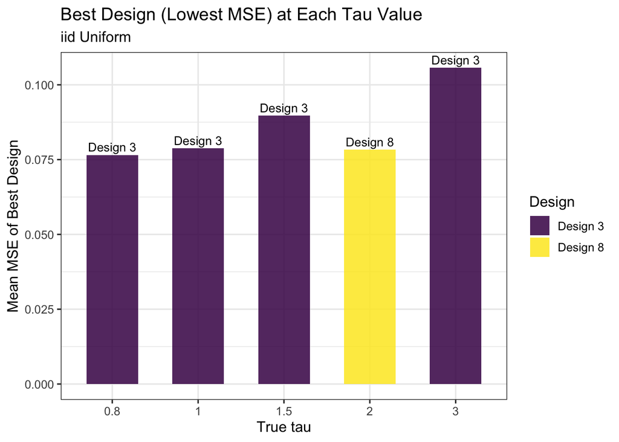

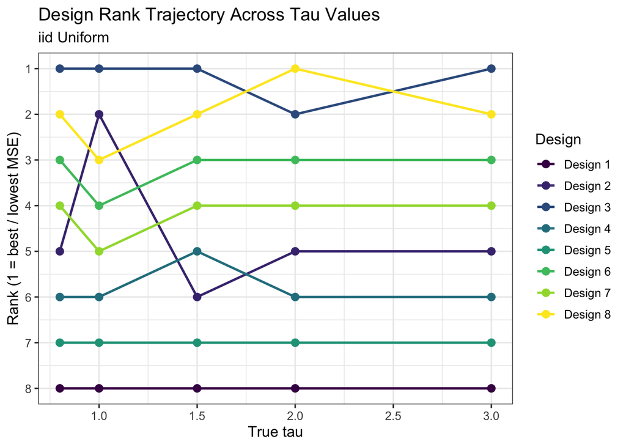

# 12 References

- Mirzaei, A. et al. (2019). Sudden unexpected death rates. *(SUD base rate 35/100,000)*
- LeSage, J. & Pace, R.K. (2009). *Introduction to Spatial Econometrics*. CRC Press.
- Bivand, R., et al. `spdep` R package.
- Bivand, R. & Piras, G. `spatialreg` R package.
- R packages used: `dplyr`, `tidyr`, `ggplot2`, `viridis`, `knitr`, `kableExtra`, `gridExtra`, `digest`

# 13 Appendix: Output Files

Output files for the design recommendation analysis.

| File | Contents | Location |
| --- | --- | --- |
| MLE_combined_design_recommendations.pdf | Raw figure output: all recommendation plots | results/ |
| sim_results_MLE_combined_20260322_151030.rds | Source data: 2560 MLE scenarios x 16 columns | results/sim_data/ |
| MLE_design_recommendation_report.pdf | This narrative companion report | results/ |